# Assemble POC, environmental and UVP data

Author

Thelma Panaïotis

## Load data

```r
source("utils.R")

load("data/00.carbon_data.Rdata")
load("data/01.all_env.Rdata")
load("data/03.uvp_profiles.Rdata")
rm(coast)
```

## Round coordinates of env and UVP data to match carbon data

- **Case 1: carbon data from Wang**

Carbon data is given on a 2°×2° grid, so we need to round env and UVP coordinates to match the same grid. Carbon longitudes are odd so we need to floor longitude with `precision = 2` and then add 1 to the result. Carbon latitudes are even so we can just round with `precision = 2`.

- **Case 2: carbon data from Argo floats**

```r
# Choose C data source
c_data <- "wang"
#c_data <- "argo"
if (c_data == "wang") {
  df_c <- df_c_mod
} else {
  df_c <- df_c_argo
}
```

### Env data

```r
env <- env %>%
  arrange(lon, lat) %>%
  rowwise() %>%
  mutate(
    lon = ifelse(
      c_data == "wang",
      # for wang, floor longitude and add 1 because carbon longitudes are odd
      roundp(lon, precision = 2, f = floor) + 1,
      # for argo, round to 8°
      roundp(lon, precision = 8, f = round)
    ),
    lat = ifelse(
      c_data == "wang",
      # for wang, round latitude because carbon latitudes are even
      roundp(lat, precision = 2, f = round),
      # for argo, round to 4°
      roundp(lat, precision = 8, f = round)
    )
  ) %>%
  # Average all values on carbon pixels
  group_by(lon, lat) %>%
  summarise_all(mean, na.rm = TRUE) %>%
  ungroup()
```

### UVP data

We can start by plotting a map of UVP profiles.

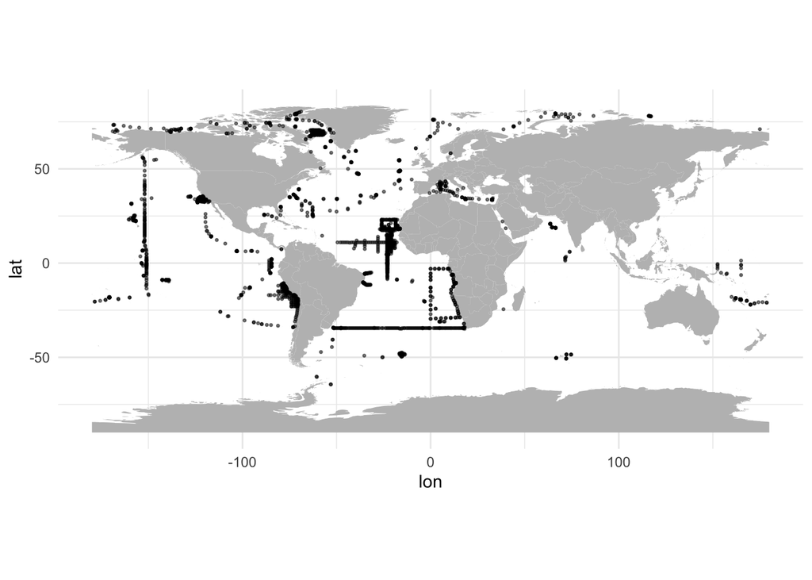

```r
profiles %>%
  ggplot() +
  geom_polygon(data = world, aes(x = lon, y = lat, group = group), fill = "gray") +
  geom_point(aes(x = lon, y = lat), alpha = 0.5, size = 0.5) +
  coord_quickmap()
```

Now let’s round the coordinates and replot the map. We also need to average UVP data on our new grid, but before that let’s also compute the number of UVP profiles per carbon pixel.

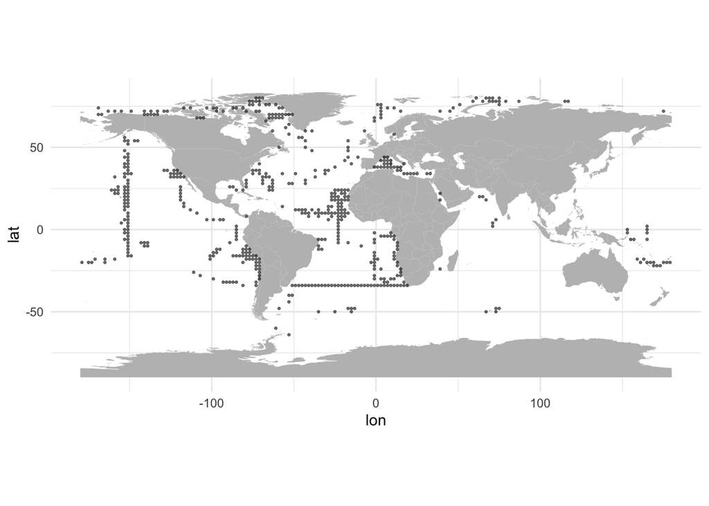

```r
profiles <- profiles %>%
  # Drop profile identification
  select(-profile_id) %>%
  rowwise() %>%
  mutate(
    lon = ifelse(
      c_data == "wang",
      # for wang, floor longitude and add 1 because carbon longitudes are odd
      roundp(lon, precision = 2, f = floor) + 1,
      # for argo, round to 8°
      roundp(lon, precision = 8, f = round)
    ),
    lat = ifelse(
      c_data == "wang",
      # for wang, round latitude because carbon latitudes are even
      roundp(lat, precision = 2, f = round),
      # for argo, round to 4°
      roundp(lat, precision = 8, f = round)
    )
  )

n_profiles <- profiles %>% count(lon, lat)

profiles <- profiles %>%
  # Average all values on carbon pixels
  group_by(lon, lat) %>%
  summarise_all(mean, na.rm = TRUE) %>%
  ungroup()

profiles %>%
  ggplot() +
  geom_polygon(data = world, aes(x = lon, y = lat, group = group), fill = "gray") +
  geom_point(aes(x = lon, y = lat), alpha = 0.5, size = 0.5) +
  coord_quickmap()
```

UVP profiles are now aligned on the 2°×2° grid. We can also plot the number of UVP profiles per pixel.

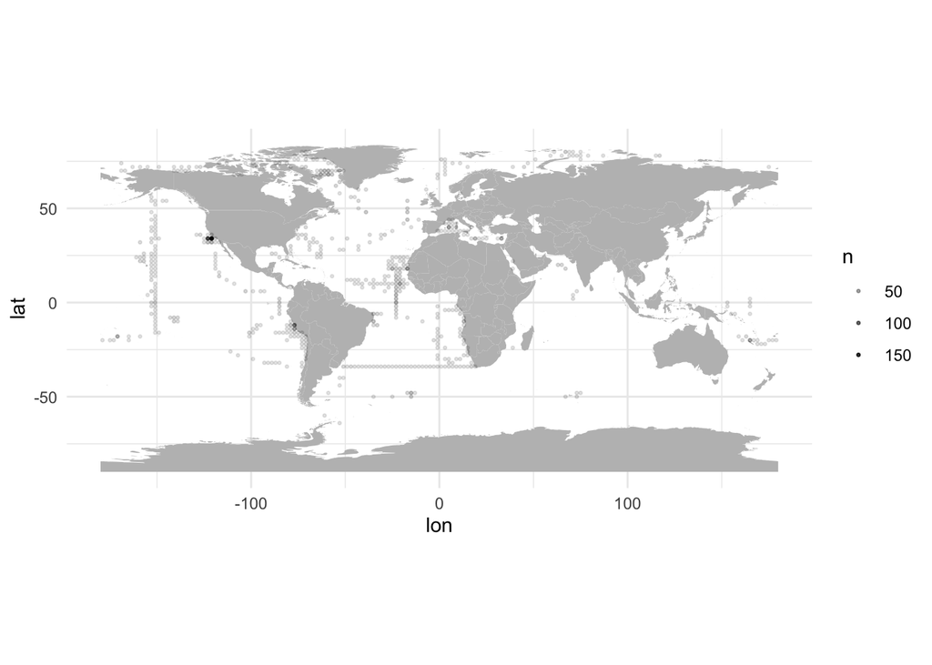

```r
n_profiles %>%
  ggplot() +
  geom_polygon(data = world, aes(x = lon, y = lat, group = group), fill = "gray") +
  geom_point(aes(x = lon, y = lat, alpha = n), size = 0.5) +
  coord_quickmap()
```

We can notice a strong sampling in the California current and in the Peruvian upwelling.

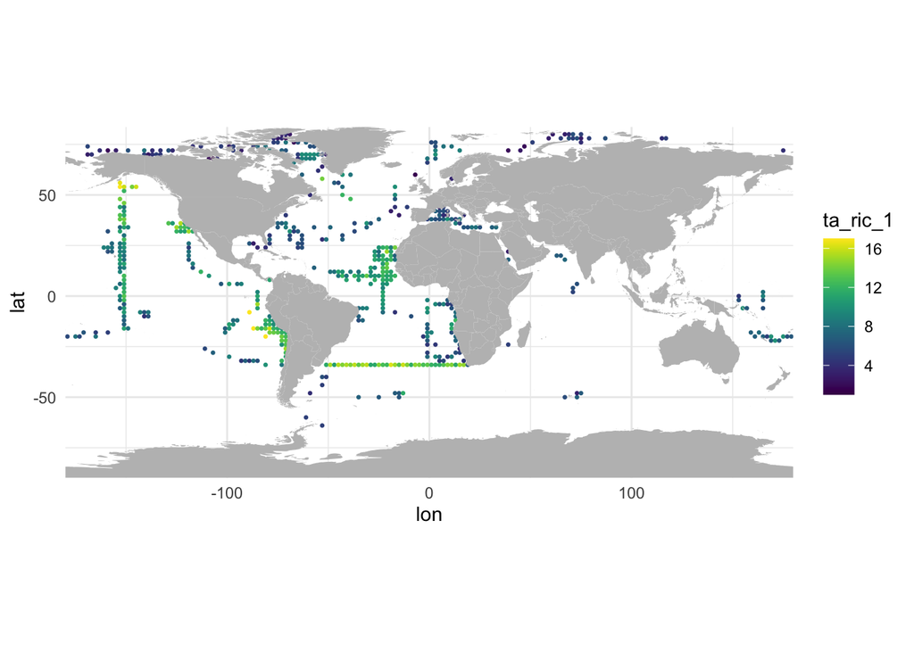

```r
ggmap(profiles, "ta_ric_1", type = "point")
```

## Assemble env, UVP and carbon data

Since all three datasets use the same round coordinates, we can join them together. As a result, we will only get env and carbon data where UVP data is available.

```r
df <- profiles %>%
  left_join(env,  by = join_by(lon, lat)) %>%
  left_join(df_c, by = join_by(lon, lat)) %>%
  select(lon, lat, everything())
```

```r
profiles
```

```
# A tibble: 533 × 37
     lon   lat    datetime abund biovol ta_ric_1 ta_ric_2 ta_ric_3 ta_div_1
   <dbl> <dbl>       <dbl> <dbl>  <dbl>    <dbl>    <dbl>    <dbl>    <dbl>
 1  -179   -20 1425959974.  14.5   69.6     5.5     1.71     1.47     1.51
 2  -175   -20 1426041923   20     93.8     8       2.34     1.79     1.66
 3  -173   -20 1426118340.  11     53.6     5.5     1.88     1.66     1.44
 4  -171   -18 1426630497   16.6  127.      6.37    1.93     1.59     1.53
 5  -169    70 1402365546   27    681.      3       0.607    0.577    0.671
 6  -169    74 1378948400.  33.7 3949.      5.33    1.23     0.918    0.916
 7  -167    70 1402997200   24.2 2666.      4.25    1.02     0.869    1.19
 8  -165   -20 1427620897   16     60.8     8       2.52     2        1.75
 9  -165   -18 1427609055   13    289.      5       1.56     1.39     1.48
10  -163    72 1401372963   18    126.      4       1.04     0.943    0.761
# ℹ 523 more rows
# ℹ 28 more variables: ta_eve_1 <dbl>, ta_div_2 <dbl>, ta_div_3 <dbl>,
#   ta_eve_3 <dbl>, ta_mast <dbl>, ss_slope <dbl>, ss_inter <dbl>,
#   mo_size_mean <dbl>, mo_size_sd <dbl>, mo_grey_mean <dbl>, mo_grey_sd <dbl>,
#   mo_elon_mean <dbl>, mo_elon_sd <dbl>, mo_ghet_mean <dbl>, mo_ghet_sd <dbl>,
#   mo_dis <dbl>, mo_mpd <dbl>, mo_nnd <dbl>, mo_eve <dbl>, mo_ric <dbl>,
#   mo_div <dbl>, mo_ori <dbl>, mo_spe <dbl>, mo_ide_mo_dim1 <dbl>, …
```

Our dataset contains 533 points.

Now, we can plot POC data at locations of UVP profiles.

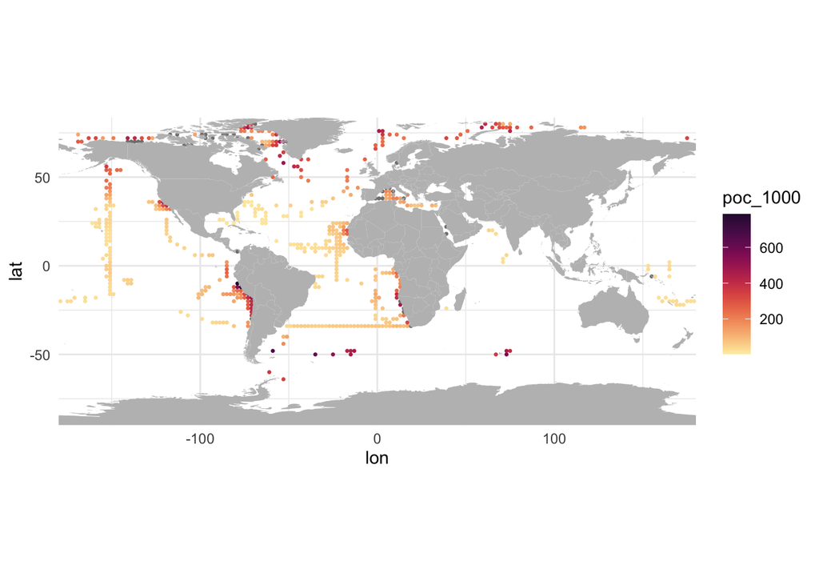

```r
ggmap(df, "poc_1000", type = "point", palette = scale_colour_cmocean(name = "matter"))
```

Or temperature.

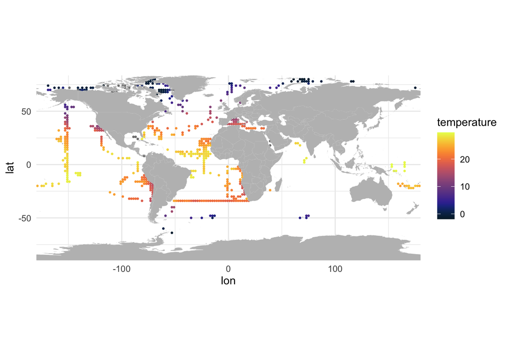

```r
ggmap(df, "temperature", type = "point", palette = scale_colour_cmocean(name = "thermal"))
```

In both cases, we notice that some POC and temperature data is not available at some UVP locations.

```r
summary(df)
```

```
      lon               lat            datetime             abund
 Min.   :-179.00   Min.   :-64.00   Min.   :1.214e+09   Min.   : 11.00
 1st Qu.: -97.00   1st Qu.:-16.00   1st Qu.:1.330e+09   1st Qu.: 24.00
 Median : -45.00   Median : 16.00   Median :1.407e+09   Median : 52.00
 Mean   : -46.56   Mean   : 16.65   Mean   :1.391e+09   Mean   : 76.56
 3rd Qu.:  -1.00   3rd Qu.: 40.00   3rd Qu.:1.439e+09   3rd Qu.:107.50
 Max.   : 179.00   Max.   : 80.00   Max.   :1.532e+09   Max.   :564.95

     biovol             ta_ric_1         ta_ric_2        ta_ric_3
 Min.   :    17.26   Min.   : 1.000   Min.   :0.000   Min.   :0.1562
 1st Qu.:   272.11   1st Qu.: 6.000   1st Qu.:1.393   1st Qu.:0.8752
 Median :   721.80   Median : 8.000   Median :1.984   Median :1.2209
 Mean   :  3652.05   Mean   : 8.418   Mean   :1.878   Mean   :1.1826
 3rd Qu.:  1941.70   3rd Qu.:11.000   3rd Qu.:2.394   3rd Qu.:1.4631
 Max.   :281614.73   Max.   :17.000   Max.   :3.592   Max.   :2.5000

    ta_div_1        ta_eve_1          ta_div_2         ta_div_3
 Min.   :0.000   Min.   :0.07554   Min.   :0.0000   Min.   :0.07273
 1st Qu.:1.011   1st Qu.:0.58259   1st Qu.:0.8619   1st Qu.:0.22172
 Median :1.494   Median :0.69120   Median :1.2399   Median :0.30481
 Mean   :1.366   Mean   :0.66897   Mean   :1.1570   Mean   :0.36938
 3rd Qu.:1.714   3rd Qu.:0.80726   3rd Qu.:1.4657   3rd Qu.:0.48624
 Max.   :2.384   Max.   :1.00000   Max.   :2.1892   Max.   :1.00000

    ta_eve_3         ta_mast           ss_slope         ss_inter
 Min.   :0.1112   Min.   :0.01041   Min.   :-5.093   Min.   :0.7572
 1st Qu.:0.2990   1st Qu.:0.09756   1st Qu.:-2.967   1st Qu.:1.3620
 Median :0.4204   Median :0.17015   Median :-2.723   Median :1.6254
 Mean   :0.5007   Mean   :0.20235   Mean   :-2.660   Mean   :1.6026
 3rd Qu.:0.6187   3rd Qu.:0.28937   3rd Qu.:-2.266   3rd Qu.:1.8058
 Max.   :1.9643   Max.   :0.66667   Max.   :-1.018   Max.   :2.6577

  mo_size_mean        mo_size_sd     mo_grey_mean        mo_grey_sd
 Min.   :-4.31812   Min.   :1.783   Min.   :-5.51772   Min.   :0.5363
 1st Qu.:-1.05368   1st Qu.:3.101   1st Qu.:-0.07709   1st Qu.:1.5282
 Median :-0.09212   Median :3.539   Median : 0.40507   Median :1.7739
 Mean   : 0.08145   Mean   :3.527   Mean   : 0.47883   Mean   :1.8389
 3rd Qu.: 1.16321   3rd Qu.:3.919   3rd Qu.: 1.34176   3rd Qu.:2.0078
 Max.   : 6.42109   Max.   :6.869   Max.   : 4.00199   Max.   :3.6710

```

[output cut: 73 more lines]

```
 Min.   :-1.6799   Min.   :0.000000   Min.   :3.188   Min.   :13.17
 1st Qu.:-0.9460   1st Qu.:0.000040   1st Qu.:3.595   1st Qu.:30.70
 Median :-0.7022   Median :0.000049   Median :4.096   Median :41.31
 Mean   :-0.6198   Mean   :0.000093   Mean   :4.115   Mean   :37.57
 3rd Qu.:-0.3121   3rd Qu.:0.000065   3rd Qu.:4.559   3rd Qu.:45.57
 Max.   : 0.6665   Max.   :0.002494   Max.   :5.292   Max.   :53.21
 NA's   :4         NA's   :4          NA's   :4       NA's   :4
    poc_exp           poc_100           poc_1000            att
 Min.   :  155.6   Min.   :  100.3   Min.   :  3.815   Min.   :0.01051
 1st Qu.: 1635.5   1st Qu.: 1082.0   1st Qu.: 36.899   1st Qu.:0.02012
 Median : 2178.0   Median : 1458.3   Median : 69.583   Median :0.02960
 Mean   : 2884.7   Mean   : 1950.9   Mean   :136.925   Mean   :0.05369
 3rd Qu.: 3405.9   3rd Qu.: 2270.0   3rd Qu.:207.491   3rd Qu.:0.04765
 Max.   :21513.7   Max.   :14537.9   Max.   :785.500   Max.   :0.20302
 NA's   :42        NA's   :42        NA's   :42        NA's   :42
```

Let’s get rid of these points.

```r
df <- df %>% drop_na()
```

We still have 439 points in our dataset.

Let’s redraw our POC map.

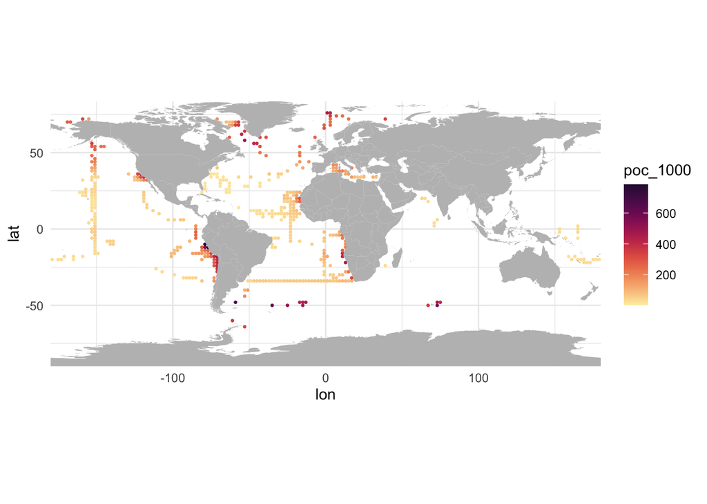

```r
ggmap(df, "poc_1000", type = "point", palette = scale_colour_cmocean(name = "matter"))
```

## Compute Wang attenuation residuals from temp

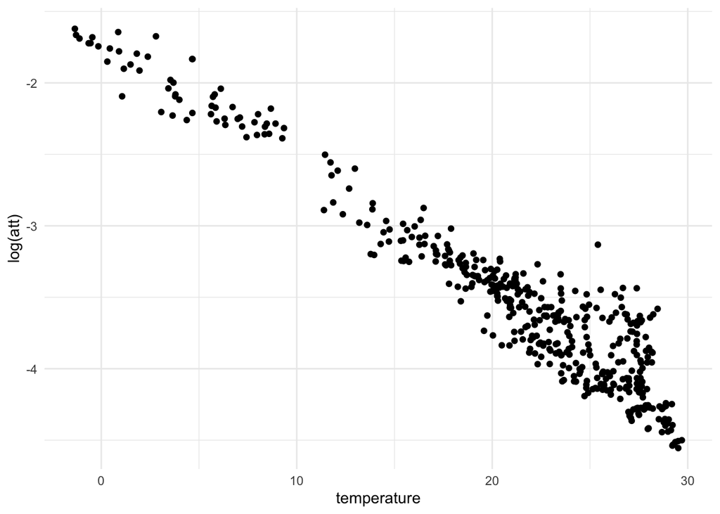

```r
ggplot(df) +
  geom_point(aes(x = temperature, y = log(att)))
```

log(att) has a nice linear response to temperature. Let’s fit it.

```r
df <- df %>% mutate(att_log = log(att))
att_fit <- lm(att_log ~ temperature, data = df)
summary(att_fit) # quite good fit
```

```
Call:
lm(formula = att_log ~ temperature, data = df)

Residuals:
     Min       1Q   Median       3Q      Max
-0.36099 -0.14100 -0.01308  0.10992  0.76852

Coefficients:
             Estimate Std. Error t value Pr(>|t|)
(Intercept) -1.700704   0.027125  -62.70   <2e-16 ***
temperature -0.086592   0.001238  -69.92   <2e-16 ***
---
Signif. codes:  0 '***' 0.001 '**' 0.01 '*' 0.05 '.' 0.1 ' ' 1

Residual standard error: 0.1925 on 437 degrees of freedom
Multiple R-squared:  0.918, Adjusted R-squared:  0.9178
F-statistic:  4889 on 1 and 437 DF,  p-value: < 2.2e-16
```

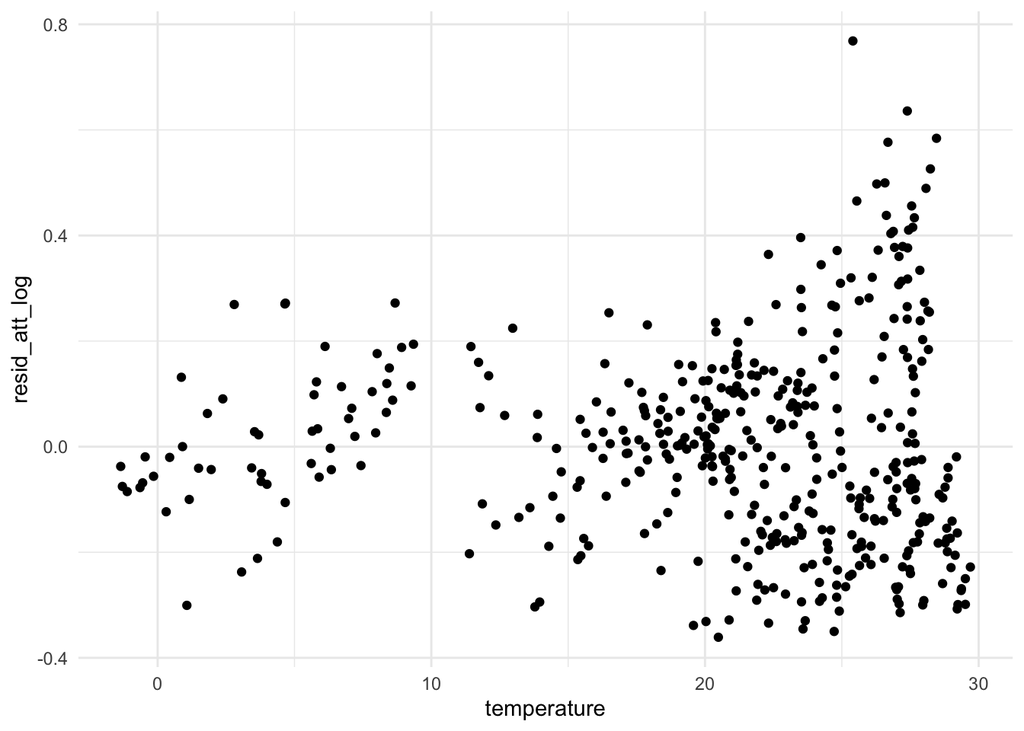

```r
df <- df %>%
  mutate(
  pred_att_log = predict(att_fit),
  #pred_att = exp(pred_log_att),
  resid_att_log = att_log - pred_att_log
  )

# Plot residuals (log)
ggplot(df) + geom_point(aes(x = temperature, y = resid_att_log))
```

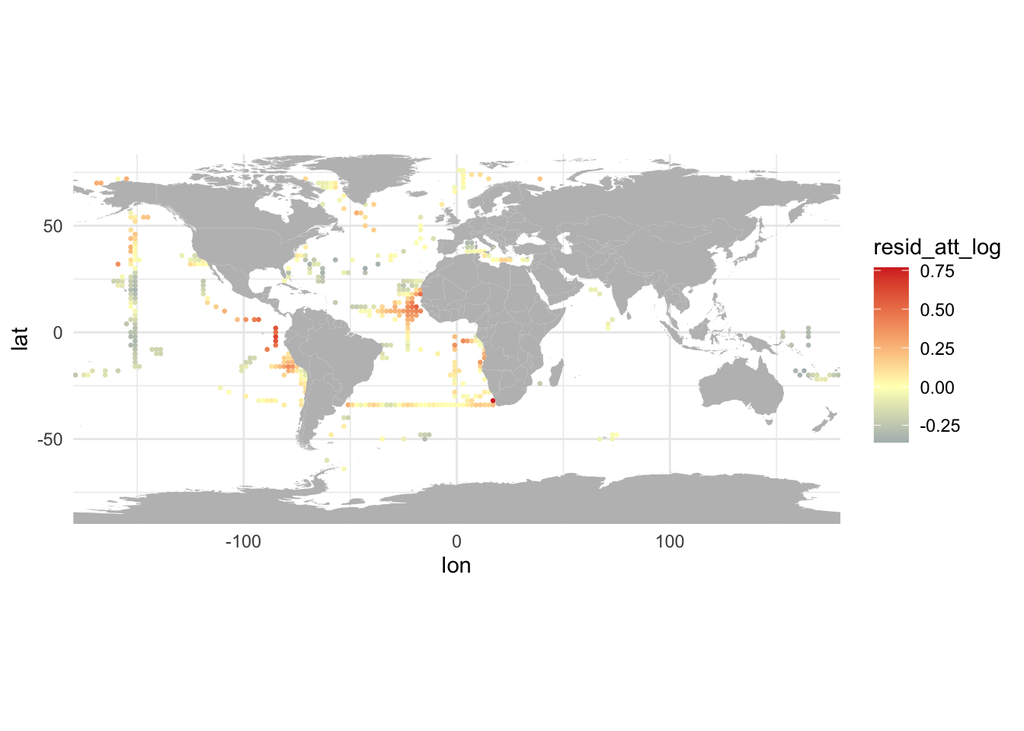

```r
ggmap(
  df,
  var = "resid_att_log",
  type = "point",
  palette = scale_colour_gradient2(low = "#4575b4", mid = "#ffffbf", high = "#d73027")
)
```

## Save the resulting dataset

```r
save(df, file = file.path(data_dir, "04.all_data.Rdata"))
```